# Temporal Autocorrelation

Finn Reddington

2025-04-16

## Plan for Dealing with Temporal Autocorrelation

#### 1 - Prep: Make sure all recordings are sub-setted to the same sampling intensity (to correct for different duty cycles during data collection)

#### 2 - Diagnosis: How severe is TA?

#### 3 - Addressing it:

```
       (i) Subsampling
       (ii) Model time: this may account for greatest source of variablity
       (iii) Using autoregressive models
```

## 1. Sub-sample to get all recs to 1 in 3 mins sampling intensity:

1. First load and wrangle:

```r
# RDA Data Wrangle
setwd("C:/Users/fr15610/OneDrive - University of Bristol/Desktop/Deep_Learning_and_Acoustic_Indices")

# Wrangling and setup----
## Load packages and data ----
library(tidyverse)
library(vegan)
library(corrplot)
library(car)
library(mvabund)
library(scales)
library(ggvegan)
library(ggrepel)
library(ggExtra)
library(ggfortify)
library(ggplot2)
library(GGally)
library(glmmTMB)
library(gllvm)
library(ape)
library(readxl)
library(patchwork)
library(ggpubr)
library(packfor)
library(gridExtra)

# Load data
# Load the DL features that were calulated in Python ('Kimbe_features.csv'):
# For final submission:
# data_feats <- read_csv("C:/Reef soundscapes with AI/Results/PCNN_features/Kimbe_features.csv")
# For working:
load("Data/features.Rdata")

## Wrangle feats ----
DL_feat <-
  features %>% rename(feat = `...1`) %>%
  pivot_longer(cols = all_of(colnames(features)[-1]), names_to = "Filename", values_to = "val") %>%
  #  separate_wider_delim(Filename, delim = "_", too_many = "merge", names = c("Filename", "x"), cols_remove = TRUE) %>% # split to delete extra timestamp info
  # might need in final code but not for .RData object ^^
  #select(-x) %>%
  pivot_wider(names_from = feat, values_from = val)

# Format Filename to match indices:
#DL_feat$Filename <- gsub("2304", "", DL_feat$Filename) # remove the year
#DL_feat$Filename <- gsub("_(\\d{2})(\\d{2})\\d{2}$", "_\\1_\\2", DL_feat$Filename) # format as 'MM_hh_mm'

#Check for NAs:
DL_feat <- na.omit(DL_feat)
rm(features)

## Wrangle indices data_inds ----
# Load the indices from the output folder ('Kimbe_indices.csv')
# data_inds  <- read_csv("C:/Reef soundscapes with AI/Results/PCNN_features/Kimbe_indices.csv") #for final code
data_inds <- read_csv("C:/Users/fr15610/OneDrive - University of Bristol/Desktop/soundscape_AI/Reef soundscapes with AI/Results/PCNN_features/data/compound_index.csv")

data_inds <- data_inds %>%
  rename('Filename' = minute) %>% # rename column
  select(-1) # remove row number col

data_inds <- data_inds %>%
  mutate(reef = sub("^(.*?)_.*", "\\1", Filename)) %>%
  select(-c(fish_Hf, shrimp_Hf)) %>% # remove Hf as correlated w/ H
  select(Filename, reef, everything())

# remove st dev cols:
cols_to_remove <- grep("_std", names(data_inds))
data_inds <- data_inds[-cols_to_remove]

# remove full spectrum cols:
cols_to_remove <- grep("full_", names(data_inds))
data_inds <- data_inds[-cols_to_remove]

# Rename cols to be less suggestive:
data_inds <- data_inds %>% # 'fish' becomes 'low_freq'
  rename_with(~ gsub("^fish", "low_freq", .x), starts_with("fish"))
data_inds <- data_inds %>% # 'shrimp' becomes 'high_freq'
  rename_with(~ gsub("^shrimp", "high_freq", .x), starts_with("shrimp"))

# Reformat Filename col:
data_inds$Filename <- gsub("\\.WAV$", "", data_inds$Filename, ignore.case = TRUE) # remove the '.WAV' suffix
data_inds$Filename <- gsub("2304", "", data_inds$Filename) # remove the year
data_inds$Filename <- gsub("_(\\d{2})(\\d{2})\\d{2}$", "_\\1_\\2", data_inds$Filename) # format as 'MM_hh_mm'

# Check for NAs:
data_inds <- na.omit(data_inds)

# Split time variable:
data_inds <- data_inds %>%
  extract(Filename, into = c("date", "hour", "minute"),
          regex = ".*_(\\d{2})_(\\d{2})_(\\d{2})", remove = FALSE) %>%
  mutate(datetime = paste(date, hour, minute, sep = "_"),
         date = as.integer(date),
         hour = as.integer(hour),
         minute = as.integer(minute))

# create a 'diurnal'col
data_inds <- data_inds %>%
  mutate(hour = as.integer(hour), # Ensure 'hour' is an integer for comparison
         diurnal = ifelse(hour >= 6 & hour < 18, "day", "night"))

# Rename the reefs so legend looks good:
data_inds <- data_inds %>%
  rename("Reef" = reef) %>%
  mutate(Reef = case_when(
    Reef %in% c("firstreef") ~ "First Reef",
    Reef %in% c("lubaluba") ~ "Lubaluba",
    Reef %in% c("lui") ~ "Lui",
    Reef %in% c("tuare") ~ "Tuare",
    Reef %in% c("inglis") ~ "Inglis",
    Reef %in% c("ema") ~ "Emma",
    Reef %in% c("joelles") ~ "Joelles",
    Reef %in% c("kimbe") ~ "Kimbe Island",
    Reef %in% c("garove") ~ "Garove",
    Reef %in% c("narega1") ~ "Narega West",
    Reef %in% c("narega2") ~ "Narega East",
    TRUE ~ Reef  # In case there are any other values not covered above
  ))

# Add habitat col:
data_inds <- data_inds %>%
  mutate(Habitat = case_when(
    Reef %in% c("First Reef", "Lubaluba", "Lui") ~ "Inshore",
    Reef %in% c("Inglis", "Emma", "Joelles") ~ "Pinnacle",
    Reef %in% c("Tuare", "Kimbe Island") ~ "Island",
    Reef %in% c("Garove", "Narega West", "Narega East") ~ "Offshore Island",
    TRUE ~ "unknown"
  ))

# Order and remove redundant cols:
data_inds <- data_inds %>%
  select(-c(hour, minute)) %>%
  select(Filename, Reef, Habitat, datetime, date, diurnal, everything())
```

### Subset the reefs so they have the same sampling intensity:

Recordings were 1 minute long with sleep cycles of:

5 secs = Emma, Inglis, Kimbe Island, Garove, Narega1, Narega 2

30 secs = Joelles

120 secs = First Reef, Lubaluba, Lui, Tuare

```r
data_inds <- data_inds %>%
  arrange(Reef, datetime) %>%
  group_by(Reef) %>%
  mutate(row = row_number()) %>%
  filter(
    case_when(
      Reef %in% c("Emma", "Garove", "Inglis", "Kimbe Island", "Narage East", "Narage West") ~ row %% 3 == 1,
      Reef == "Joelles" ~ row %% 2 == 1,
      TRUE ~ TRUE  # Keep all for 120s interval reefs
    )
  ) %>%
  select(-row) %>%
  ungroup()

# Prepare data for RDA ----
# get metadata, left-join ensures its the same order
metadata <- DL_feat %>% select(Filename) %>%
  left_join(data_inds, by = "Filename")

# Check for NAs
metadata <- na.omit(metadata)

DL_feat_filtered <- inner_join(DL_feat, data_inds, by="Filename", keep = FALSE)
DL_feat_filtered <- DL_feat_filtered %>%
  select(names(DL_feat))
DL_feat <- DL_feat_filtered

# Make sure they match:
identical(metadata[['Filename']], DL_feat[['Filename']])# check they're the same
```

```
## [1] TRUE
```

```r
#remove from env to avoid confusion
rm(data_inds);rm(DL_feat_filtered)

head(DL_feat)
```

```
## # A tibble: 6 × 129
##   Filename   `0`     `1`   `2`   `3`   `4`   `5`   `6`     `7`   `8`   `9`  `10`
##   <chr>    <dbl>   <dbl> <dbl> <dbl> <dbl> <dbl> <dbl>   <dbl> <dbl> <dbl> <dbl>
## 1 firstre…     0 0       1.14      0     0     0     0 0.0198      0 0.562     0
## 2 firstre…     0 2.24e-5 1.10      0     0     0     0 0.0148      0 0.633     0
## 3 firstre…     0 0       1.10      0     0     0     0 0.00912     0 0.655     0
## 4 firstre…     0 8.42e-4 1.08      0     0     0     0 0.0120      0 0.723     0
## 5 firstre…     0 0       1.10      0     0     0     0 0.0119      0 0.672     0
## 6 firstre…     0 0       0.440     0     0     0     0 0.139       0 1.19      0
## # ℹ 117 more variables: `11` <dbl>, `12` <dbl>, `13` <dbl>, `14` <dbl>,
## #   `15` <dbl>, `16` <dbl>, `17` <dbl>, `18` <dbl>, `19` <dbl>, `20` <dbl>,
## #   `21` <dbl>, `22` <dbl>, `23` <dbl>, `24` <dbl>, `25` <dbl>, `26` <dbl>,
## #   `27` <dbl>, `28` <dbl>, `29` <dbl>, `30` <dbl>, `31` <dbl>, `32` <dbl>,
## #   `33` <dbl>, `34` <dbl>, `35` <dbl>, `36` <dbl>, `37` <dbl>, `38` <dbl>,
## #   `39` <dbl>, `40` <dbl>, `41` <dbl>, `42` <dbl>, `43` <dbl>, `44` <dbl>,
## #   `45` <dbl>, `46` <dbl>, `47` <dbl>, `48` <dbl>, `49` <dbl>, `50` <dbl>, …
```

```r
head(metadata)
```

```
## # A tibble: 6 × 17
##   Filename        Reef  Habitat datetime  date diurnal low_freq_ACI low_freq_ADI
##   <chr>           <chr> <chr>   <chr>    <int> <chr>          <dbl>        <dbl>
## 1 firstreef_20_0… Firs… Inshore 20_08_33    20 day             162.         1.72
## 2 firstreef_20_0… Firs… Inshore 20_08_36    20 day             165.         1.70
## 3 firstreef_20_0… Firs… Inshore 20_08_39    20 day             163.         1.68
## 4 firstreef_20_0… Firs… Inshore 20_08_42    20 day             163.         1.71
## 5 firstreef_20_0… Firs… Inshore 20_08_45    20 day             162.         1.70
## 6 firstreef_20_0… Firs… Inshore 20_08_48    20 day             155.         1.77
## # ℹ 9 more variables: low_freq_H <dbl>, low_freq_M <dbl>, low_freq_BI <dbl>,
## #   high_freq_ACI <dbl>, high_freq_ADI <dbl>, high_freq_BI <dbl>,
## #   high_freq_H <dbl>, high_freq_M <dbl>, NDSI <dbl>
```

**We now have two data sets that match up:**

- metadata - contains time/place info and acoustic indices
- DL_feat - contains the deep-learning features

## 2. Check how bad the Temporal Autocorrelation is:

Prepare the data for Redundancy Analysis (RDA): center Y and standardize X

```r
# scale Y vars:
DL_cent <- DL_feat %>% # make a centered but not scaled version
  mutate(across(-c(1), ~ {
    scaled_vector <- as.vector(scale(., scale = FALSE))
    return(scaled_vector)
  }, .names = "{col}"))  %>%
  column_to_rownames(var = "Filename")

# centre and scale acoustic_indices
metadata_sd <- metadata %>%
  select(-c(Reef:diurnal)) %>%
  column_to_rownames(var = "Filename") %>%
  mutate(across(everything(), ~ {
    scaled_vector <- as.vector(scale(., scale = TRUE))
    return(scaled_vector)
  }, .names = "{col}"))
```

Check for collinearlity:

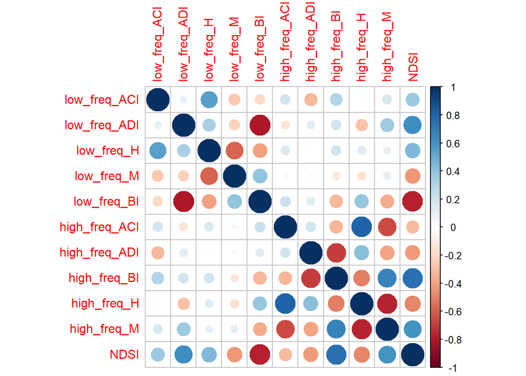

```r
# Checking assumptions ----
## collinarity in X vars ----
cor.table = cor(metadata_sd) # defo some highly correlated vars
corrplot(cor.table)
```

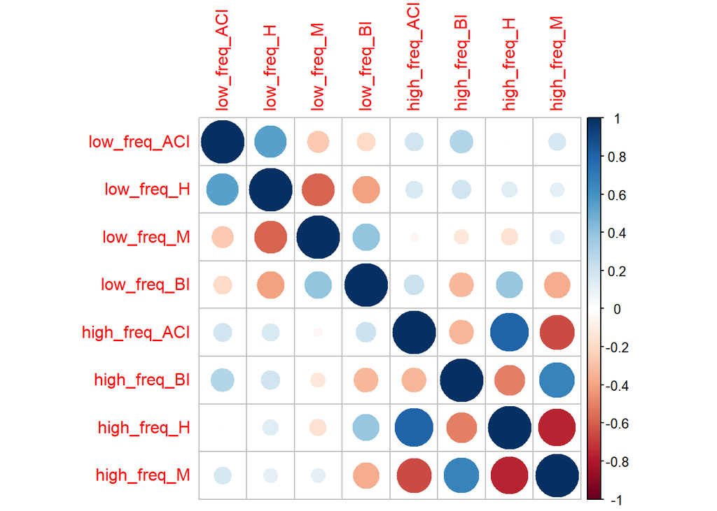

```r
# ADI and BI are correlated, NDSI is correlated. So remove ADI and NDSI
metadata_sd <- metadata_sd %>% select(-c(low_freq_ADI, high_freq_ADI))
metadata_sd <- metadata_sd %>% select(-c(NDSI))
cor.table = cor(metadata_sd) # defo some highly correlated vars
corrplot(cor.table)
```

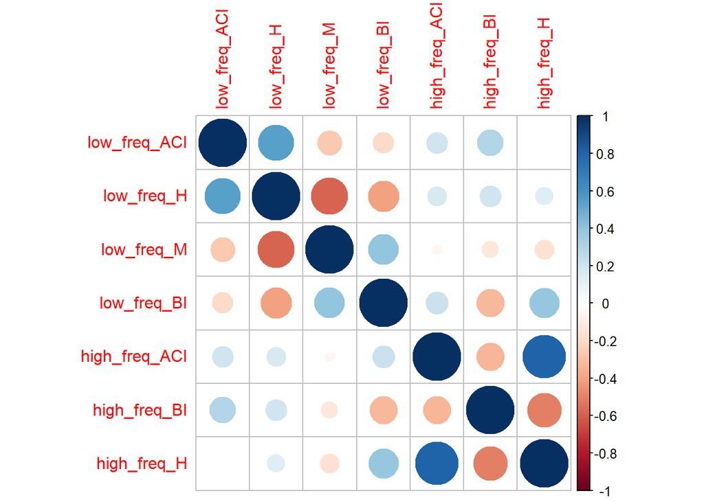

```r
# high_freq_M is still correlated highly
metadata_sd <- metadata_sd %>% select(-c(high_freq_M))
cor.table = cor(metadata_sd)
corrplot(cor.table)
```

Looks pretty good now.

Run an RDA:

```r
rda1 <- rda(DL_cent ~ low_freq_ACI + low_freq_H + low_freq_M +
                  low_freq_BI + high_freq_ACI + high_freq_BI + high_freq_H,
                data=metadata_sd,
                scale=FALSE,
                na.action=na.omit)
```

Check:

```r
RsquareAdj(rda1)
```

```
## $r.squared
## [1] 0.568381
##
## $adj.r.squared
## [1] 0.5682492
```

```r
# summary(rda1)
vif.cca(rda1)
```

```
##  low_freq_ACI    low_freq_H    low_freq_M   low_freq_BI high_freq_ACI
##      1.740491      2.283322      1.853574      1.846649      3.619358
##  high_freq_BI   high_freq_H
##      1.581263      5.041204
```

### Check Temporal Autocorrelation for a few Y variables

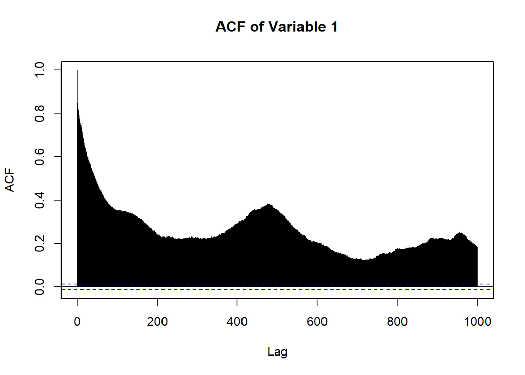

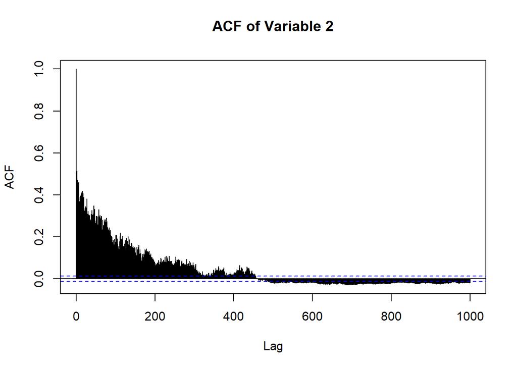

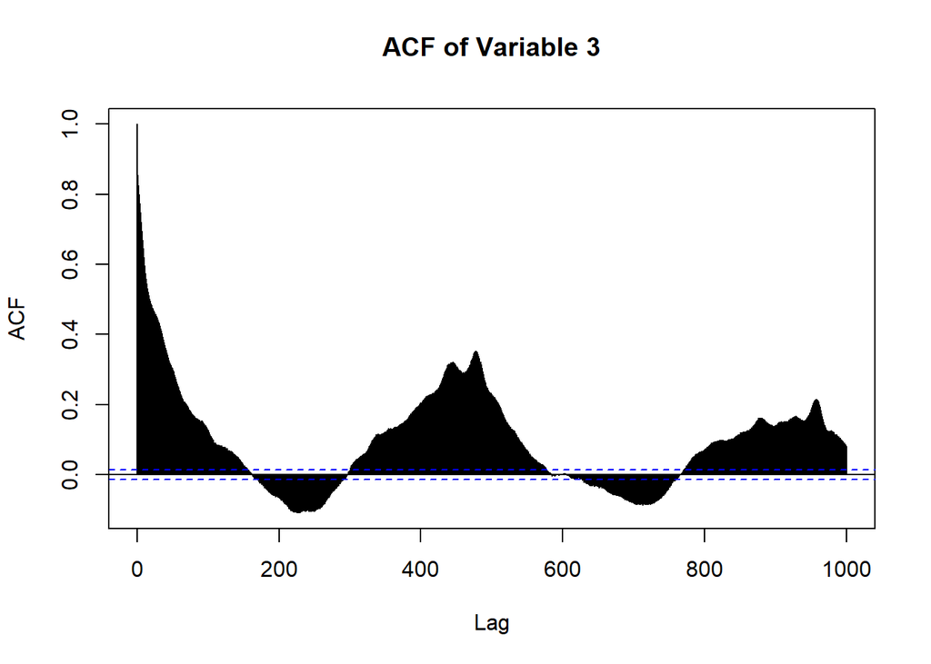

```r
res_rda1 <- residuals(rda1)

lapply(1:3, function(i) acf(res_rda1[, i], lag.max = 1000, main = paste("ACF of Variable", i)))
```

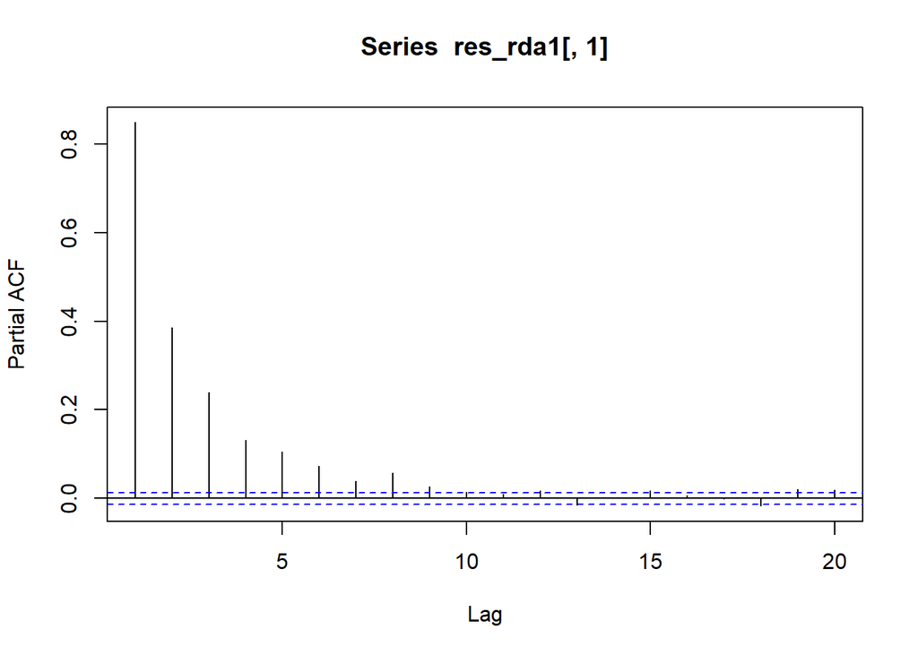

```r
pacf(res_rda1[,1], lag.max = 20)
```

```r
acf_values <- acf(res_rda1, plot = FALSE)
acf1 <- acf_values$acf[1:5]
```

Many of these residuals are highly correlated around a day, or 480 steps (1 in 3 mins sampling intensity = 20 per hour x 24). But also at longer and shorter times too:

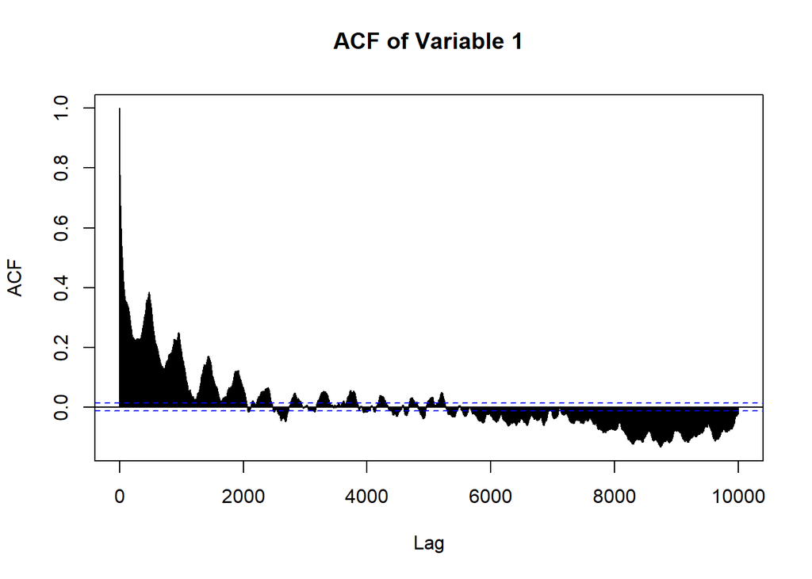

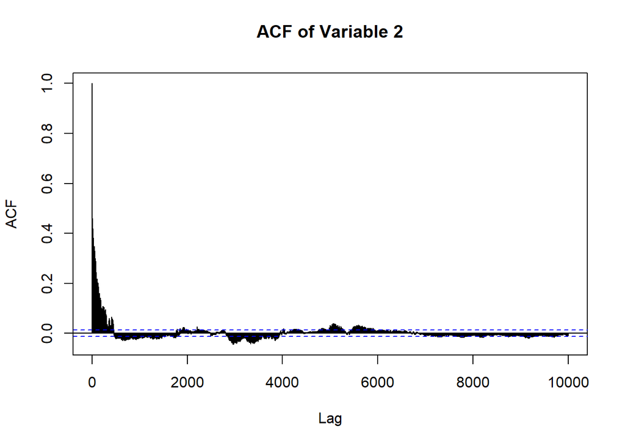

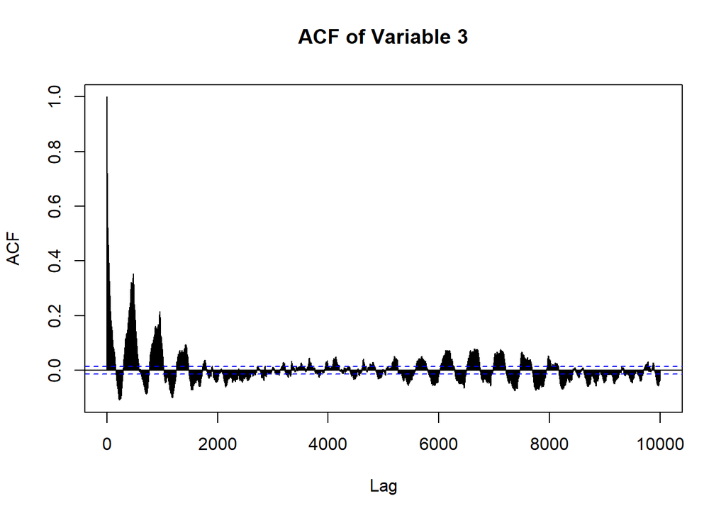

```r
# Increase 'lag.max' to explore a longer time frame
lapply(1:3, function(i) acf(res_rda1[, i], lag.max = 10000, main = paste("ACF of Variable", i)))
```

Seems to be correlated at other steps too but the **strongest is crepusclar and diurnal**. Try to account for that in the model.

An option is to try and include categorical variables for ’Day/Night’and a continuous time variable:

```r
# add cols for duirnal and reef to metadata_sd
# select categorical variables (+time_cont)
metadata_cat <- metadata %>% select(Filename, Reef, diurnal, datetime) %>%
  separate(datetime, into = c("day", "hour", "minute"), sep = "_", convert = TRUE) %>%
    mutate(datetime_full = as.POSIXct(paste(day, hour, minute), format = "%d %H %M")) %>%
  # Calculate continuous time: minutes since the earliest datetime
  mutate(time_cont = as.numeric(difftime(datetime_full, min(datetime_full), units = "mins")))

# scale numeric variables
metadata_sd <- metadata %>%
  select(-c(Reef:diurnal)) %>%
  column_to_rownames(var = "Filename") %>%
  mutate(across(everything(), ~ {
    scaled_vector <- as.vector(scale(., scale = TRUE))
    return(scaled_vector)
  }, .names = "{col}")) %>%
  rownames_to_column(var="Filename")

# Join numeric and categorical variables
metadata_sd_cat <- metadata_sd %>%
  left_join(metadata_cat, by = "Filename") %>%
  column_to_rownames(var="Filename")

# Check they're the same:
identical(metadata_sd[['low_freq_ACI']], metadata_sd_cat[['low_freq_ACI']])# check they're the same
```

```
## [1] TRUE
```

Looks good! Now, try an RDA with ‘diurnal’ as a categorical variable. Since much of the TA is associated with diunal cycles this might help account for the temporal structure of the data.

Run a partial RDA that explores variation after accounting for diurnal effects:

```r
rda2 <- rda(DL_cent ~ low_freq_ACI + low_freq_H + low_freq_M +
                  low_freq_BI + high_freq_ACI + high_freq_BI + high_freq_H + Condition(diurnal),
                data=metadata_sd_cat,
                scale=FALSE,
                na.action=na.omit)

RsquareAdj(rda2)
vif.cca(rda2)
# summary(rda2)
```

Check the acf plots:

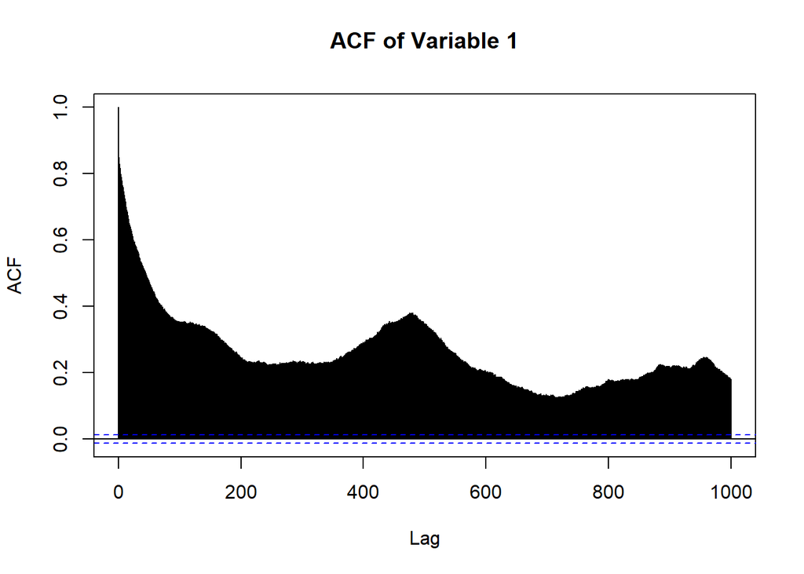

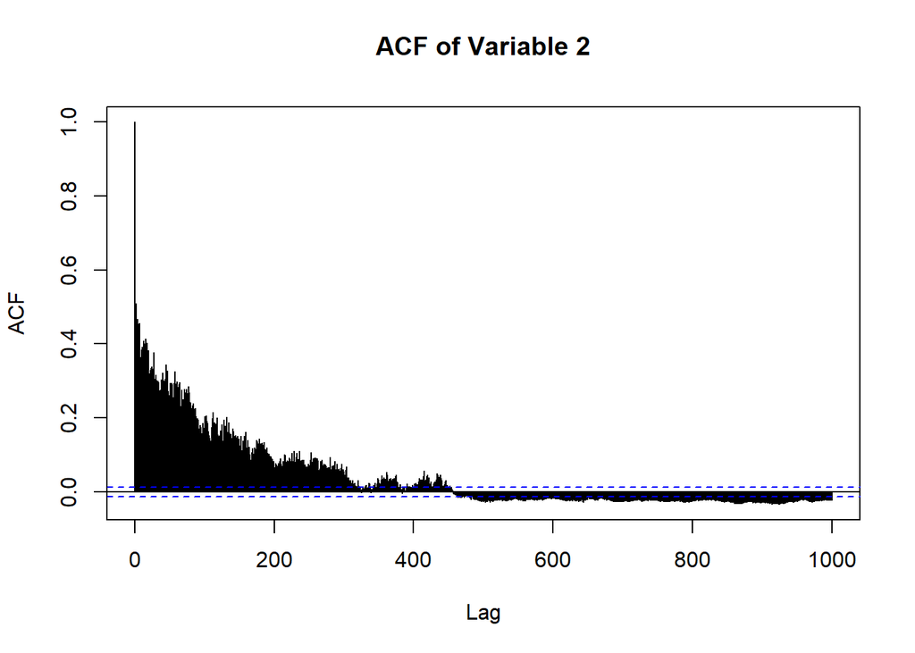

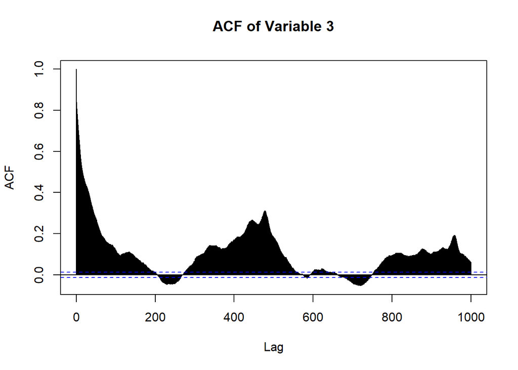

```r
res_rda2 <- residuals(rda2)

lapply(1:3, function(i) acf(res_rda2[, i], lag.max = 1000, main = paste("ACF of Variable", i)))
```

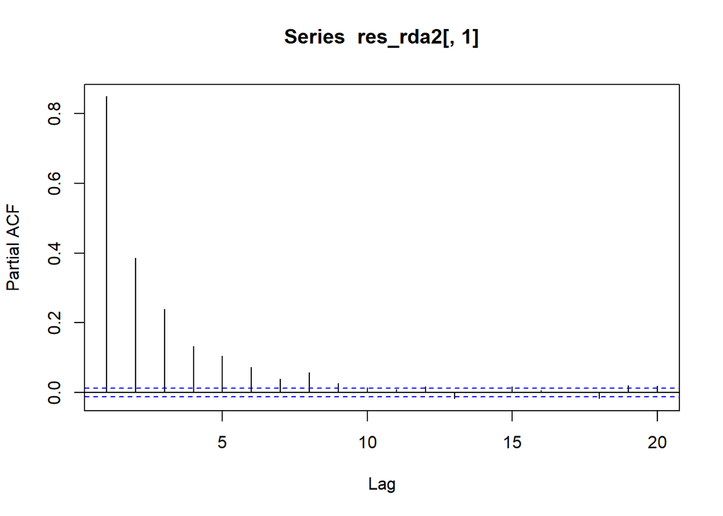

```r
pacf(res_rda2[,1], lag.max = 20)
```

```r
acf_values <- acf(res_rda2, plot = FALSE)
acf2 <- acf_values$acf[1:5]
```

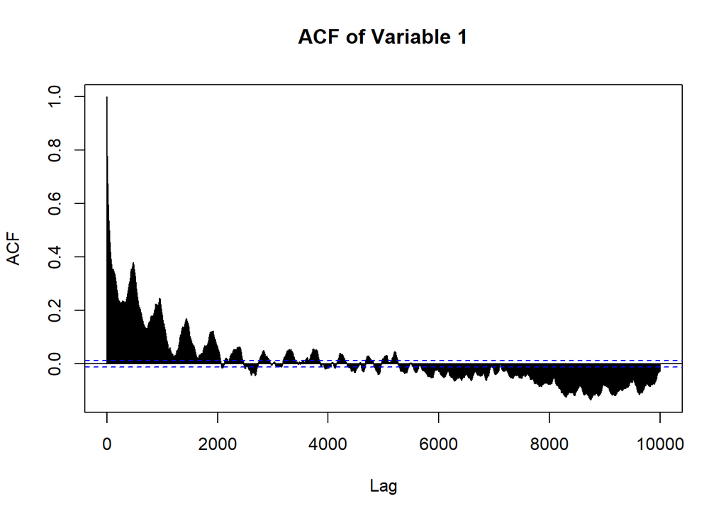

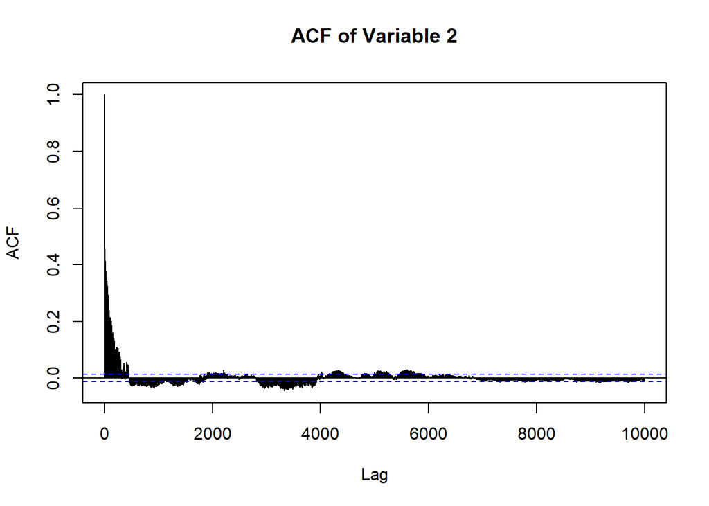

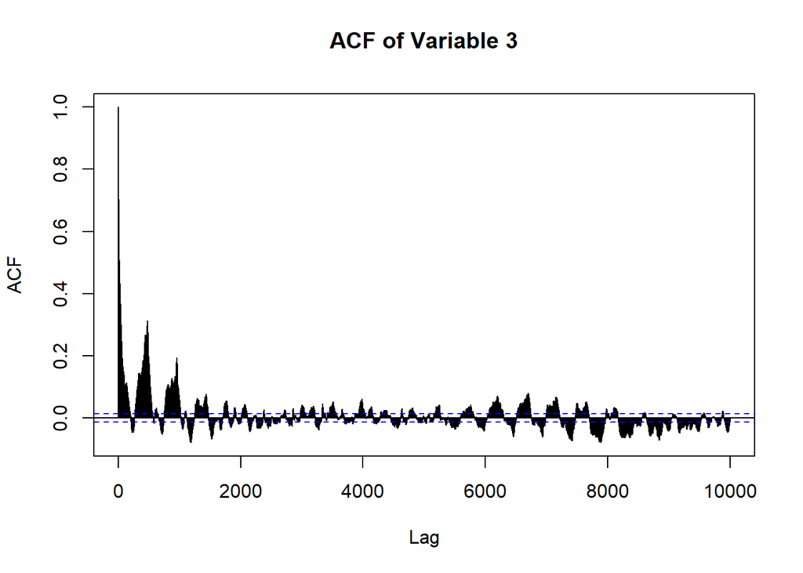

```r
lapply(1:3, function(i) acf(res_rda2[, i], lag.max = 10000, main = paste("ACF of Variable", i)))
```

OK, we can compare the acf values to see if they’re any different for the first few lags:

```r
acf1
```

```
## [1] 1.0000000 0.8488162 0.8283975 0.8161328 0.7990073
```

```r
acf2
```

```
## [1] 1.0000000 0.8492201 0.8288832 0.8166811 0.7996562
```

Basically the same. Try time as a continuous variable.

```r
rda3 <- rda(DL_cent ~ low_freq_ACI + low_freq_H + low_freq_M +
                  low_freq_BI + high_freq_ACI + high_freq_BI + high_freq_H + Condition(time_cont),
                data=metadata_sd_cat,
                scale=FALSE,
                na.action=na.omit)

RsquareAdj(rda3)
vif.cca(rda3)
# summary(rda2)
```

Check the acf plots:

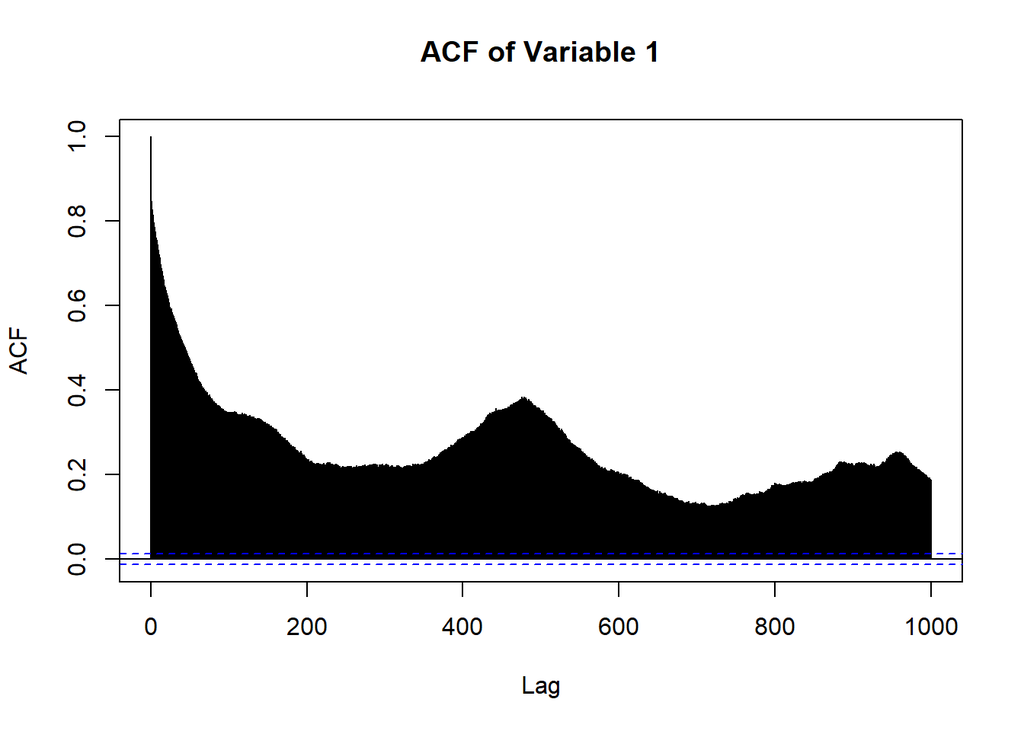

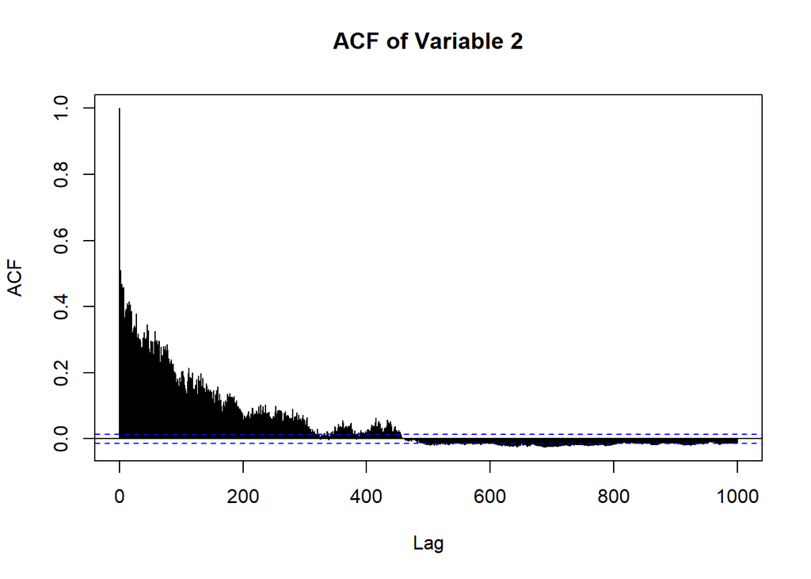

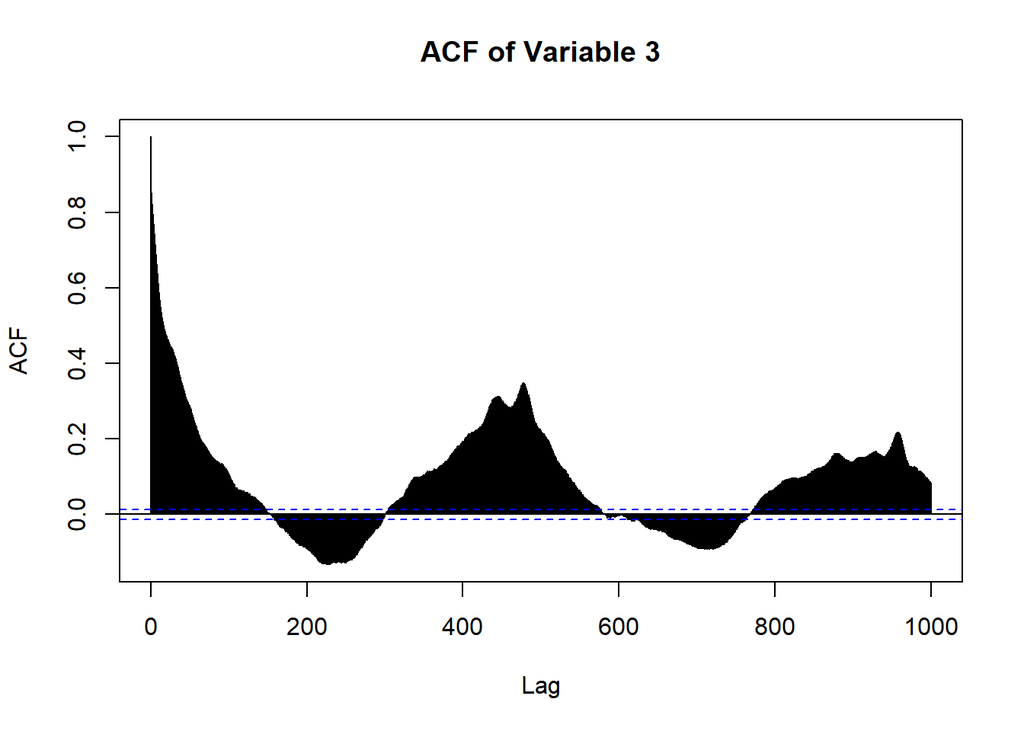

```r
res_rda3 <- residuals(rda3)

lapply(1:3, function(i) acf(res_rda3[, i], lag.max = 1000, main = paste("ACF of Variable", i)))
```

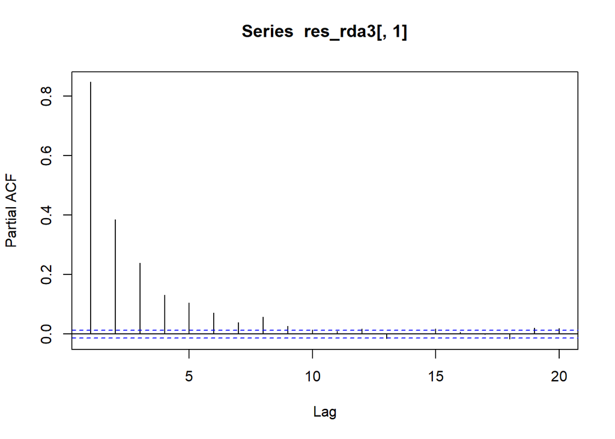

```r
pacf(res_rda3[,1], lag.max = 20)
```

```r
acf_values <- acf(res_rda3, plot = FALSE)
acf3 <- acf_values$acf[1:5]
```

compare values:

```r
acf1
```

```
## [1] 1.0000000 0.8488162 0.8283975 0.8161328 0.7990073
```

```r
acf3
```

```
## [1] 1.0000000 0.8475353 0.8269109 0.8144854 0.7972099
```

Very marginal improvement. Try time as a continuous and diurnal variable:

```r
rda4 <- rda(DL_cent ~ low_freq_ACI + low_freq_H + low_freq_M +
                  low_freq_BI + high_freq_ACI + high_freq_BI + high_freq_H + Condition(time_cont + diurnal),
                data=metadata_sd_cat,
                scale=FALSE,
                na.action=na.omit)

RsquareAdj(rda4)
```

Check the acf plots:

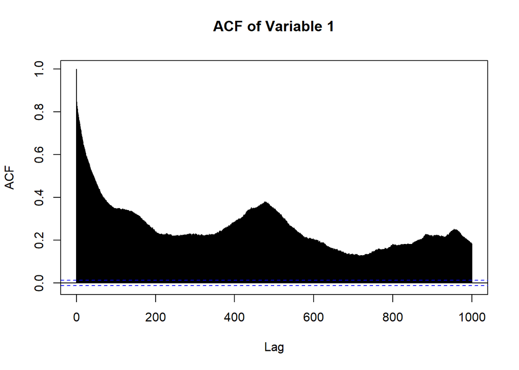

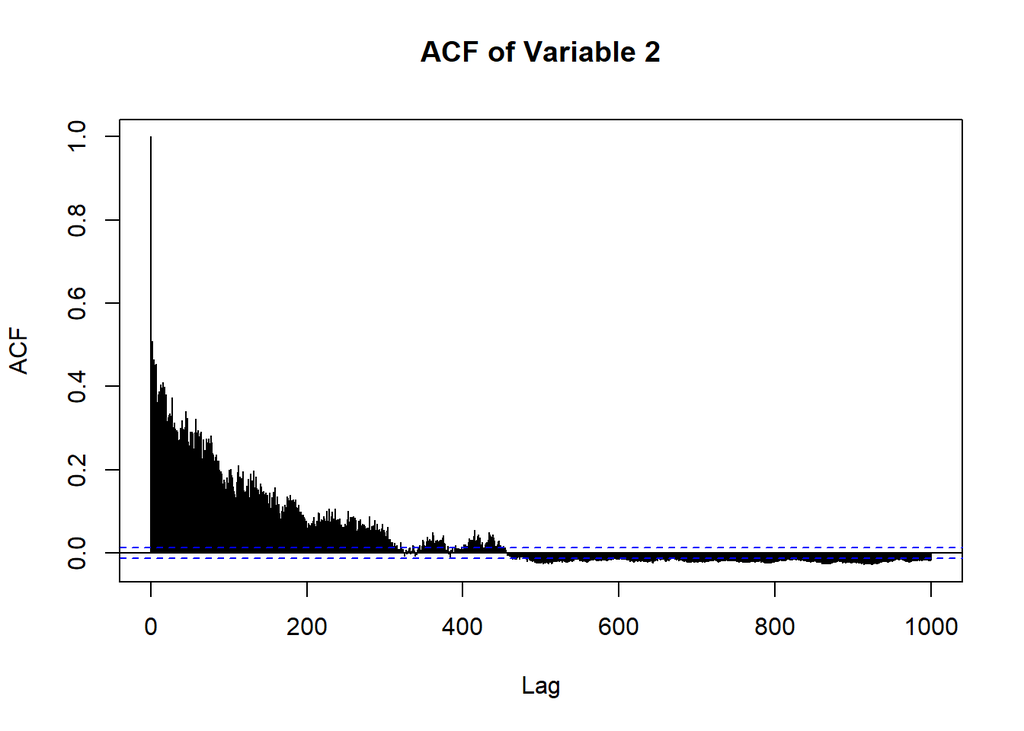

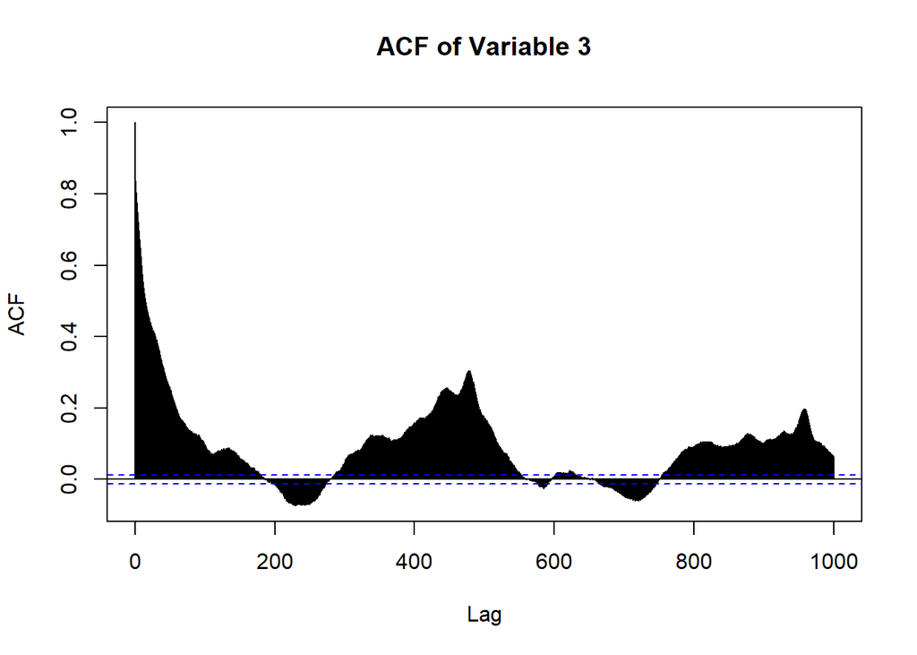

```r
res_rda4 <- residuals(rda4)

lapply(1:3, function(i) acf(res_rda4[, i], lag.max = 1000, main = paste("ACF of Variable", i)))
```

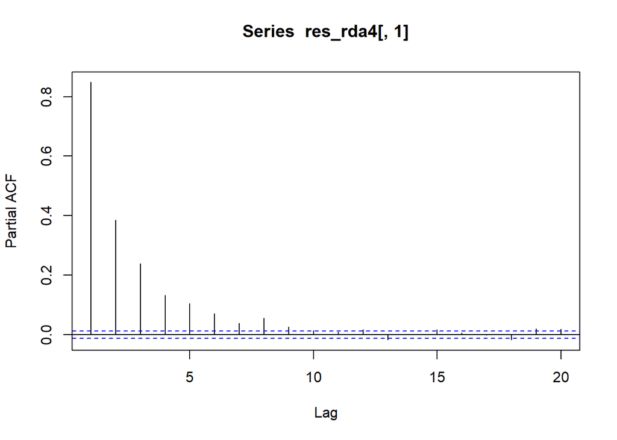

```r
pacf(res_rda4[,1], lag.max = 20)
```

```r
acf_values <- acf(res_rda4, plot = FALSE)
acf4 <- acf_values$acf[1:5]
```

compare with first model:

```r
acf1-acf4
```

```
## [1] 0.0000000000 0.0008918253 0.0010153512 0.0011100420 0.0011573883
```

```r
acf3-acf4
```

```
## [1]  0.0000000000 -0.0003889995 -0.0004711920 -0.0005373701 -0.0006400192
```

OK, so including time in the RDA as a predictor variable is not dealing with the TA. Next option is to try subsampling:

# 3. Subsampling

**Because recordings closer in time are more similar, we can lose some data and see if it’s still auto correlated. Probably it will be, because the AT is so extreme and because there’s strong dependence at a time lag of ~1 day. But let’s see…**

### 1min in 30 subsample

Let’s go extreme to see if it helps:

```r
metadata_10 <- metadata_sd_cat %>%
  filter(row_number() %% 10 == 1) %>%
  rownames_to_column(var="Filename") %>%
  arrange(Filename)

DL_cent_10 <- metadata_10 %>%
  select(Filename) %>%
  left_join(
    DL_cent %>% rownames_to_column(var = "Filename"),
    by = "Filename"
  )

identical(metadata_10[['Filename']], DL_cent_10[['Filename']])
```

```
## [1] TRUE
```

```r
DL_cent_10 <- DL_cent_10 %>%
  column_to_rownames(var = "Filename")
```

OK, lets try the basic model:

```r
rda5 <- rda(DL_cent_10 ~ low_freq_ACI + low_freq_H + low_freq_M +
                  low_freq_BI + high_freq_ACI + high_freq_BI + high_freq_H,
                data=metadata_10,
                scale=FALSE,
                na.action=na.omit)
```

Check TA for a few Y variables

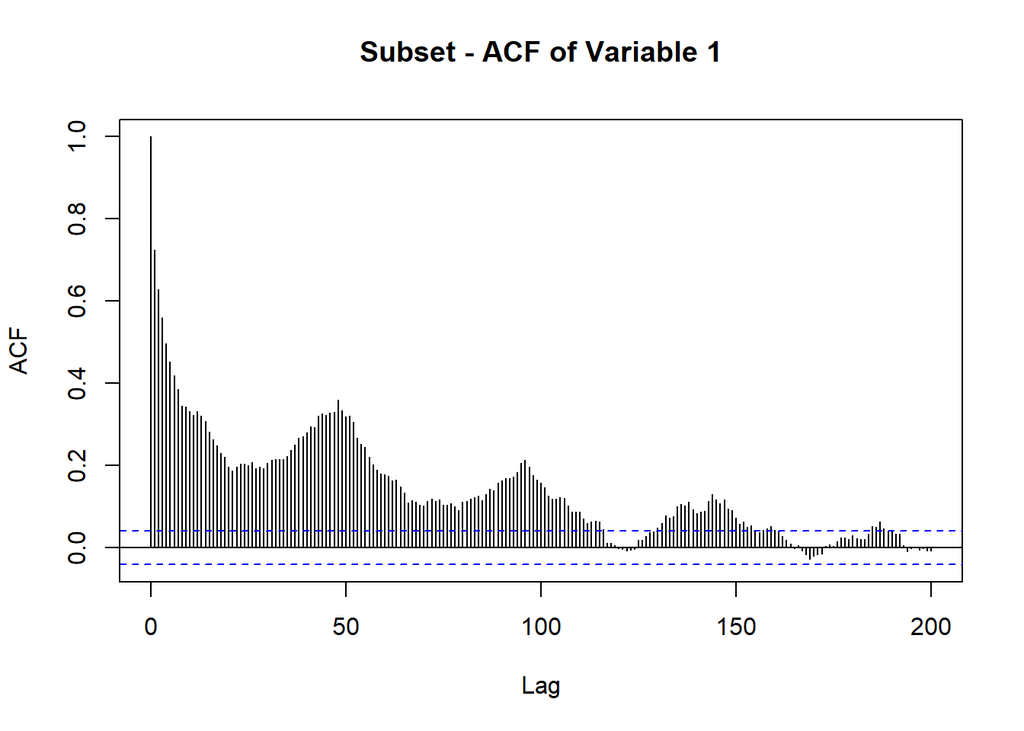

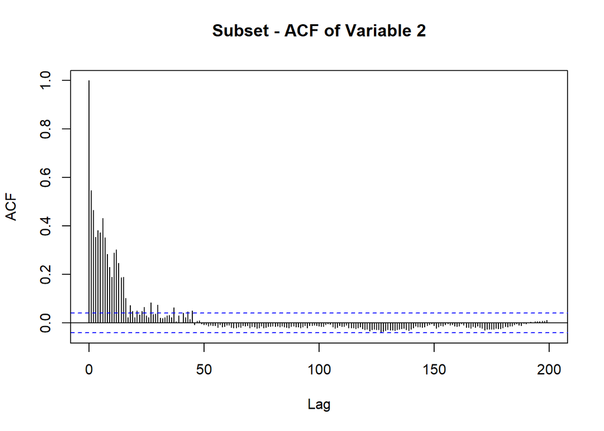

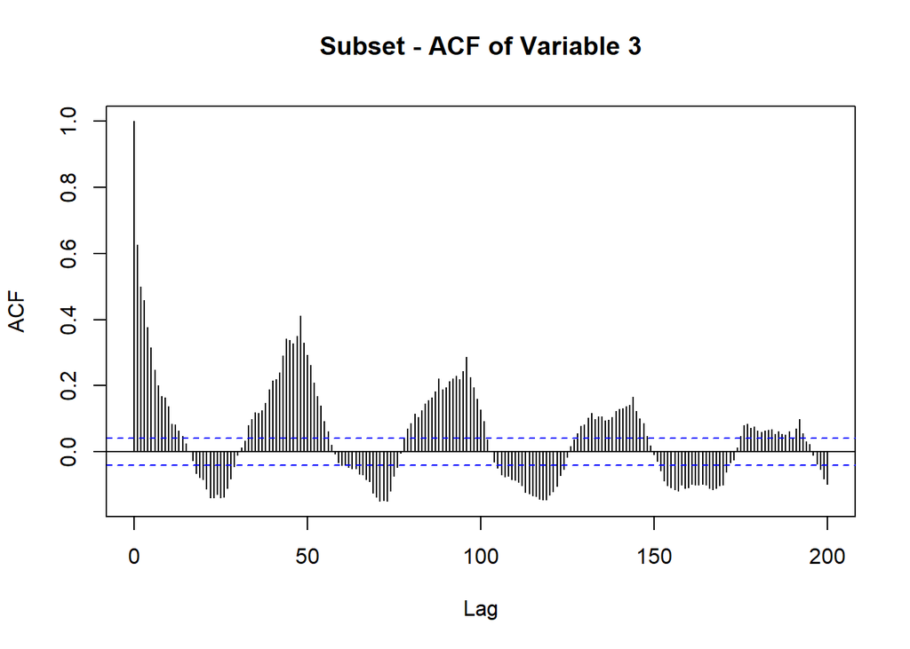

```r
res_rda5 <- residuals(rda5)

lapply(1:3, function(i) acf(res_rda5[, i], lag.max = 200, main = paste("Subset - ACF of Variable", i)))
```

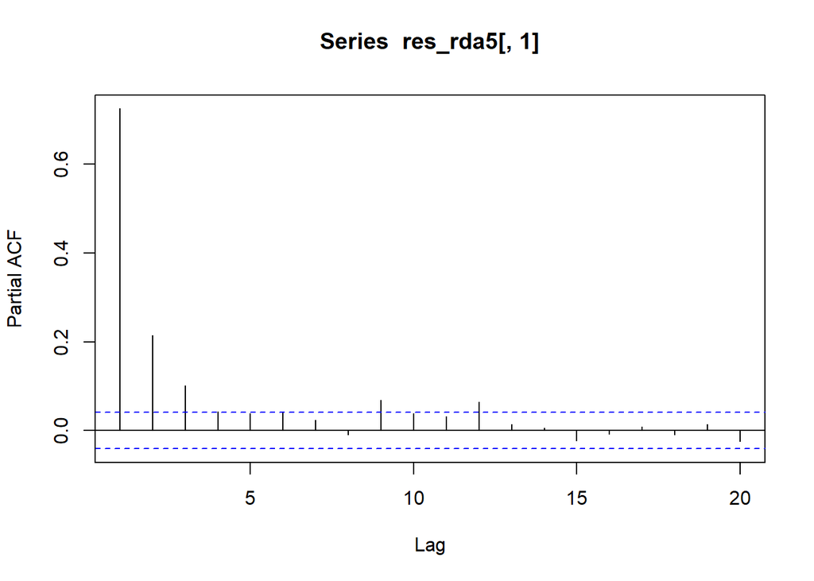

```r
pacf(res_rda5[,1], lag.max = 20)
```

```r
acf_values <- acf(res_rda5, plot = FALSE)
acf5 <- acf_values$acf[1:5]

# Compare to the full data:
lapply(1:3, function(i) acf(res_rda1[, i], lag.max = 200, main = paste("Full - ACF of Variable", i)))
```

[output not shown]